# Analysis of Film and Music Sales for Media Distributors, Inc.

Prepared by Oakland Partners

Tejas Adhikari

Spring 2025

## 1 Background

Media Distributors, Inc. is a Wichita, KY based distributor and seller of films and music for commercial purposes. For the past few years, it has managed its film and music sales separately using different applications. This division is historical as Media Distributors started distributing films and then acquired SoundMania about two years ago. As the two distribution channels were different, CTO Alvin Coelho made the decision not to integrate the SoundMania’s information systems and database with those of Media Distributors. This has not been a problem until now, however Media Distributors intends to make itself available for acquisition. To that end, an integrated view of the business, particularly sales, is needed.

This report provides key sales, revenue, and customer metrics to showcase Media Distributors business. The analysis provided is based on data from a custom-built datamart containing data extracted from two operational databases.

We have maintained the address of the customers and not the stores as the last paragraph mentions the foloowing for the whole report “The customer base is concentrated in India, China, and United States, which also serve as the top-performing markets.” an this can be achieved by using the customers address for country.

## 2 Key Business Metrics

This sections provides key revenue and customer information segmented by time, country, and business unit. Revenue numbers are in US$.

### 2.1 Sales Revenue

The year with the most sales was 2005 with a total revenue across both business units of $66,902. The country with the most sales was India with total sales across both business units in 2005 of $6,568. It was followed by the China with $5,762.

The table below shows sales revenue by country and ordered by total sales for the two most recent years, 2012 and 2013 The table is restricted to the top five countries with the most sales. The column ‘Total’ in the table represents the total for all years for which there is data and not just the past two years.

Total Revenue For Top Five Countries For Most Recent Two Years

| Revenue Per Year | Revenue Per Year 2012 | Revenue Per Year 2013 | Revenue Per Year Total (All Years) |
| --- | --- | --- | --- |
| United States | 1,033 | 750 | 8,777 |
| India | 84 | 53 | 7,298 |
| China | 0 | 0 | 5,803 |
| Brazil | 533 | 335 | 4,878 |
| Japan | 0 | 0 | 3,472 |

The table below shows the revenue broken down by quarter for the top five countries. It shows the total revenue for each quarter across all business units and years. So, for example, the column “Q1” is the total sales for music and film for all years for which there is data, which is from 2005 to 2013.

Cumulative and Average Quarterly Revenue

| Quarterly Revenue 2005 to 2013 | Quarterly Revenue 2005 to 2013 Q1 | Quarterly Revenue 2005 to 2013 Q2 | Quarterly Revenue 2005 to 2013 Q3 | Quarterly Revenue 2005 to 2013 Q4 | Quarterly Revenue 2005 to 2013 Average |
| --- | --- | --- | --- | --- | --- |
| United States | 930 | 2,087 | 4,560 | 1,201 | 1,254 |
| India | 161 | 1,398 | 5,732 | 6 | 1,043 |
| China | 41 | 1,295 | 4,467 | 0 | 829 |
| Brazil | 255 | 899 | 2,979 | 745 | 697 |
| Japan | 23 | 777 | 2,672 | 0 | 496 |

### 2.2 Customer Distribution

Customers by Business Unit

|  | Film | Music | Total |
| --- | --- | --- | --- |
| India | 60 | 2 | 62 |
| China | 53 | 0 | 53 |
| United States | 36 | 13 | 49 |
| Brazil | 28 | 5 | 33 |
| Japan | 31 | 0 | 31 |

### 2.3 Film vs Music Revenue

Revenue by year and business unit

|  | 2005 | 2006 | 2009 | 2010 | 2011 | 2012 | 2013 |
| --- | --- | --- | --- | --- | --- | --- | --- |
| Film | 66902 | 514 | 0 | 0 | 0 | 0 | 0 |
| Music | 0 | 0 | 4011 | 4329 | 4126 | 4256 | 4125 |

The graph below illustrates the quarterly growth of the film and music business over the past years for which we have data.

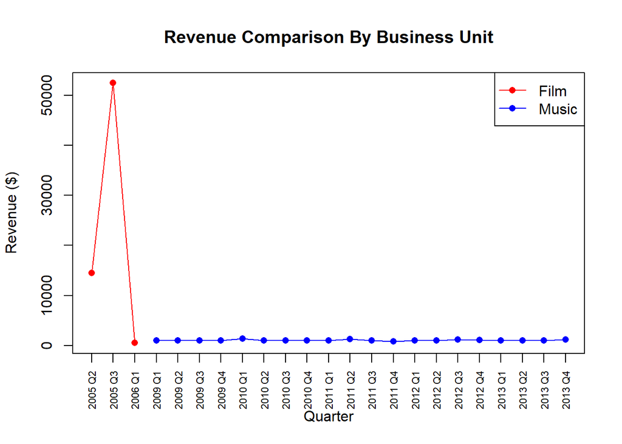

| Year | Year | Year 2005 | Year 2006 | Year 2009 | Year 2010 | Year 2011 | Year 2012 | Year 2013 | Year Total | Year Average |
| --- | --- | --- | --- | --- | --- | --- | --- | --- | --- | --- |
| India |  |  |  |  |  |  |  |  |  |  |
|  | Q1 | 0 | 23 | 0 | 1 | 9 | 0 | 4 | 37 | 5 |
|  | Q2 | 319 | 0 | 4 | 2 | 0 | 9 | 6 | 340 | 49 |
|  | Q3 | 1231 | 0 | 6 | 14 | 16 | 0 | 0 | 1267 | 181 |
|  | Q4 | 0 | 0 | 0 | 0 | 0 | 2 | 1 | 3 | 0 |
|  | Total | 1550 | 23 | 10 | 17 | 25 | 11 | 11 | 1647 | 235 |
|  | Average | 388 | 6 | 2 | 4 | 6 | 3 | 3 | 412 | 59 |
| United States |  |  |  |  |  |  |  |  |  |  |
|  | Q1 | 0 | 11 | 29 | 23 | 12 | 18 | 14 | 107 | 15 |
|  | Q2 | 222 | 0 | 33 | 29 | 32 | 18 | 20 | 354 | 51 |
|  | Q3 | 735 | 0 | 15 | 35 | 29 | 38 | 20 | 872 | 125 |
|  | Q4 | 0 | 0 | 28 | 15 | 26 | 28 | 32 | 129 | 18 |
|  | Total | 957 | 11 | 105 | 102 | 99 | 102 | 86 | 1462 | 209 |
|  | Average | 239 | 3 | 26 | 26 | 25 | 26 | 22 | 366 | 52 |
| China |  |  |  |  |  |  |  |  |  |  |
|  | Q1 | 0 | 13 | 0 | 0 | 0 | 0 | 0 | 13 | 6 |
|  | Q2 | 307 | 0 | 0 | 0 | 0 | 0 | 0 | 307 | 154 |
|  | Q3 | 1107 | 0 | 0 | 0 | 0 | 0 | 0 | 1107 | 554 |
|  | Q4 | 0 | 0 | 0 | 0 | 0 | 0 | 0 | 0 | 0 |
|  | Total | 1414 | 13 | 0 | 0 | 0 | 0 | 0 | 1427 | 714 |
|  | Average | 354 | 3 | 0 | 0 | 0 | 0 | 0 | 357 | 178 |

## 3 Summary and Recommendations

Despite these strengths, Media Distributors, Inc. faces challenges related to its siloed information systems. With plans for acquisition, the company must present a cohesive and integrated business view to appeal to potential buyers. With nearly 658 customers across 114 countries, Media Distributors should invest in customer relationship management (CRM) tools to personalize outreach and foster loyalty. Segmenting customers by preferences (film or music) and spending habits can optimize targeting.